# Синхронизация времени в Linux

Лабораторная работа №12

Элсаиед Адел

Российский университет дружбы народов, Москва, Россия

6 января 2026

# Цели и задачи работы

## Цель лабораторной работы

Получение практических навыков управления системным временем и настройки синхронизации времени в операционных системах Linux с использованием службы chrony.

# Выполнение работы

## Проверка параметров даты и времени

На виртуальных машинах **server** и **client** выполнена проверка параметров даты и времени. Установлено, что системы используют временную зону UTC, системные часы синхронизированы, а служба сетевой синхронизации времени активна.

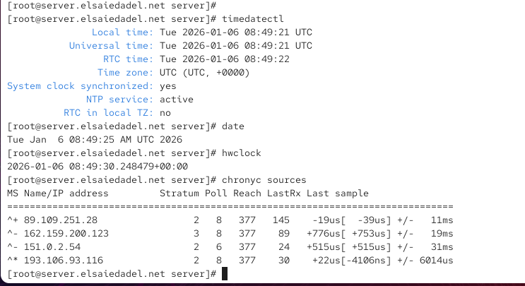

Параметры времени

## Проверка системного и аппаратного времени

Проверено текущее системное и аппаратное время. Полученные значения подтверждают корректную работу часов и отсутствие рассинхронизации между системным временем и RTC.

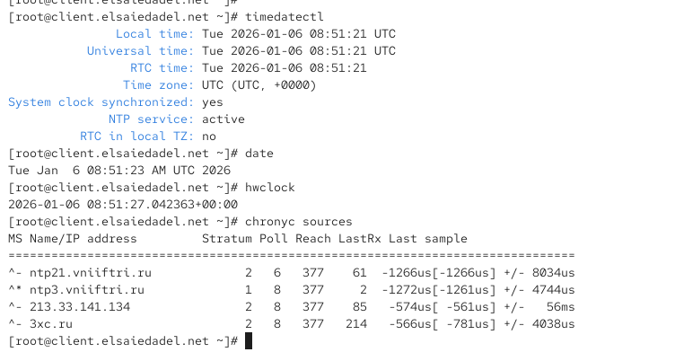

Системное и аппаратное время

## Настройка chrony на сервере

На сервере выполнено редактирование файла конфигурации chrony. Разрешён доступ клиентам из локальной сети, после чего служба синхронизации перезапущена и настроен межсетевой экран для работы NTP.

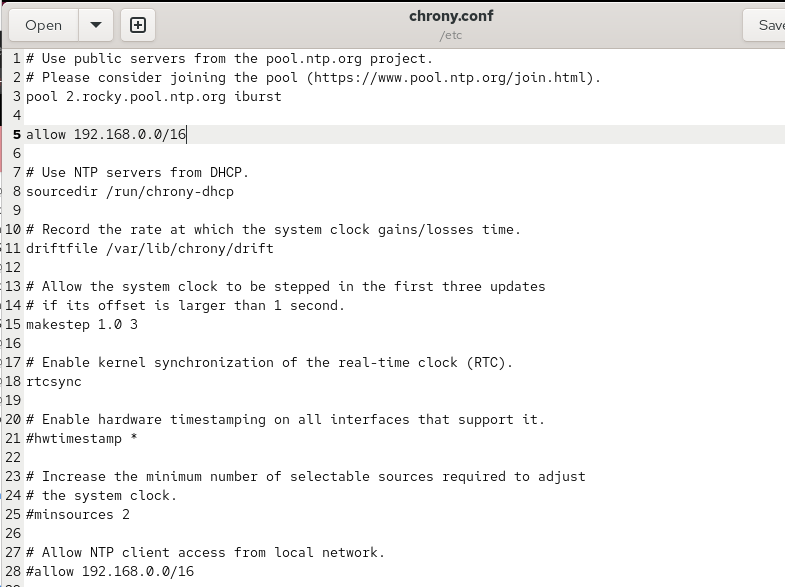

Конфигурация chrony на сервере